# Distributions

Javiera Rudolph

# Figure 1 - Descriptions of the data

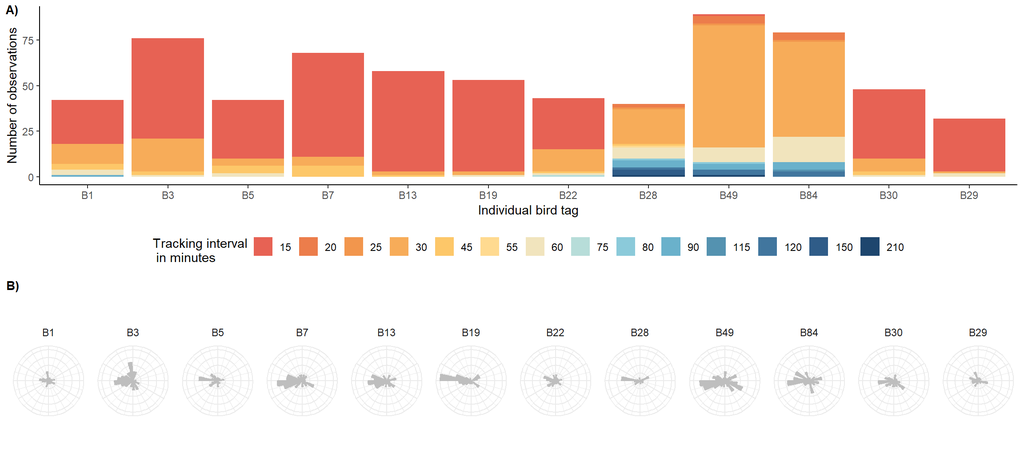

Figure 1 - A)Breakdown of the time intervals in the available data for each individual tagged bird. The majority of relocation points are recorded at 15 or 30 minute intervals. However, the intervals between relocations can get up to 210 minutes. Each relocation estimates the position of the animal, and a minimum of two consecutive relocations are necessary to estimate a trajectory, direction, and velocity. B) Distribution of relative angles for each individual. Relative angles require a minimum of three consecutive relocations to estimate the change in direction.

# Figure 2 - Density plots for velocity

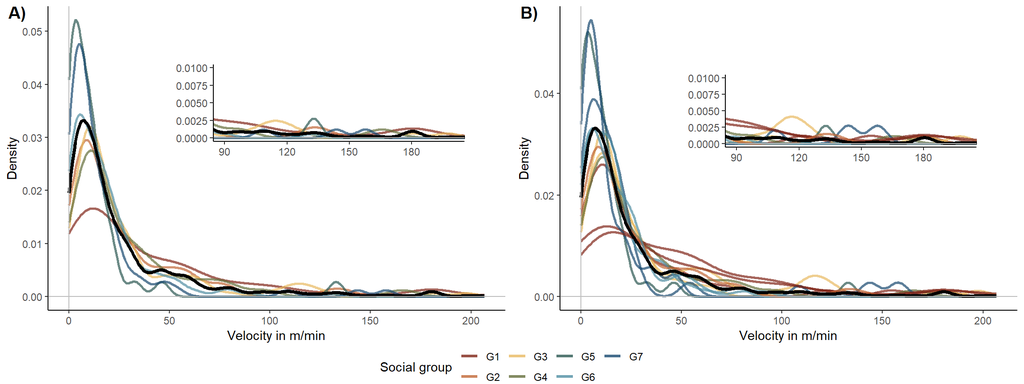

Figure 2 - Kernel density estimates for the distribution of velocity data at different pooling levels, with the dark black density curve showing complete pooling. A) Partial pooling representation of the data, where each curve displays the density of velocities across a social group. B) No pooling scenario, where each density curve is associated to a single individual’s velocity data. Individuals belonging to the same social group share the line color. Plot inserts show a zoom to the tail of the distribution of velocity data in both panels. We observe considerable variation for both partial and no pooling scenarios, when compared to the single black density curve that represents the complete pooling. Particular focus towards the tails, where certain individuals possess much higher densities for large velocities, something that gets dampened when considering pooled data for velocity densities.

# Table 1 - BIC values for models across pooling levels

Table 1 - BIC values obtained for models fitted to velocity data across pooling levels. Probability density functions considered included the Gamma, Weibull, and Lognormal distributions. Multi distribution models selected the best fitting distribution model for each social group or individual, allowing for variation not only in estimated parameters, but also in the distribution used. Based on BIC values, the best fitting model is the Multi-distribution with Partial Pooling, followed by the Lognormal PP, and Lognormal CP.

```
## # A tibble: 11 x 5
##    model dist        BIC deltaBIC_withinmodels deltaBIC_acrossmodels
##    <fct> <chr>     <dbl>                 <dbl>                 <dbl>
##  1 CP    Gamma     5710.                  25.9                  53.3
##  2 CP    Lognormal 5684.                   0                    27.5
##  3 CP    Weibull   5699.                  14.5                  41.9
##  4 PP    Gamma     5700.                  43                    43
##  5 PP    Lognormal 5677.                  20.5                  20.5
##  6 PP    Weibull   5694.                  37.8                  37.8
##  7 PP    Multi     5657.                   0                     0
##  8 NP    Gamma     5753.                  40.3                  96.9
##  9 NP    Lognormal 5733.                  19.8                  76.3
## 10 NP    Weibull   5749.                  35.5                  92
## 11 NP    Multi     5713.                   0                    56.6
```

# Figure 3 - Best fit parameters

To tell the same story, we see variation in the parameters estimated for each bootstrap under various models.

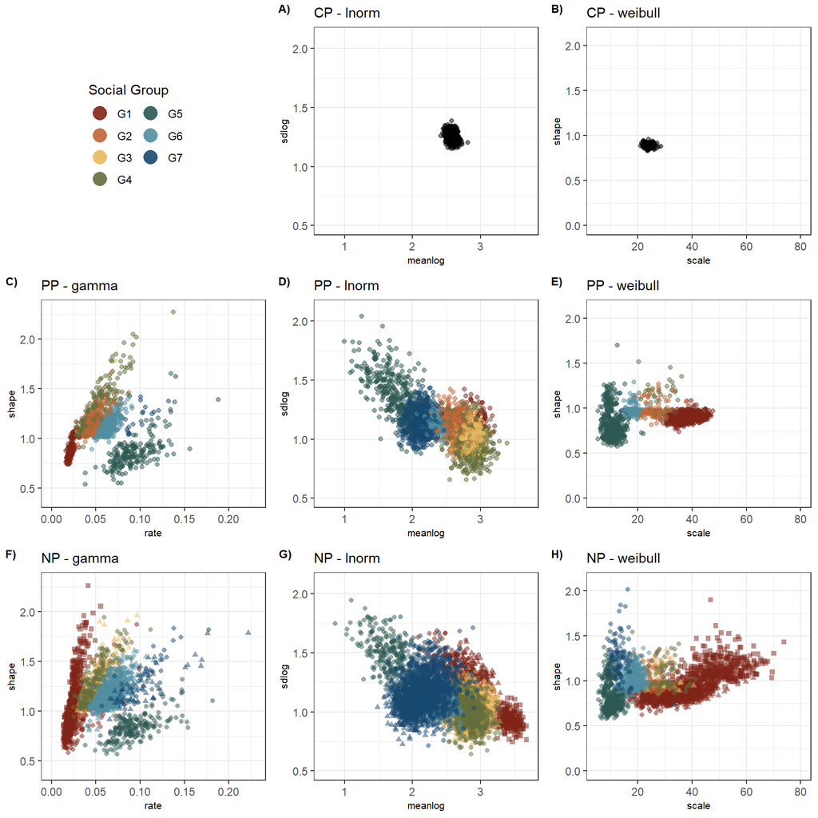

Figure 3 -Parameter space for best fitting models under the three pooling scenarios for 1000 bootstrap replicas. Complete pooling approaches showed best fitting models under the lognormal (panel A.) and weibull (B.) distributions, but no models under a gamma distribution. C)-E) Panels show placement of best fitting models under the three distributions with each color representing a different social group. Under the NP scenario (panels F.-H.) individuals belongig to the same social group are represented with a different shape.

# Figure 4 - Percent Support

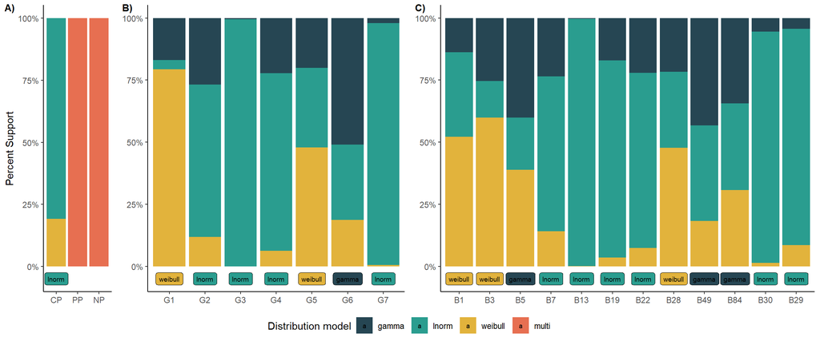

Figure 4 - Percent support for the different distribution models at the three pooling levels. Percent support is based on 1000 bootstrapped replicas for each scenario. Labels on the x axis show the best fitting model for the original datasets. A) percent support at the three pooling levels, with CP having over 50% support for the lognormal distribution, in agreement with the model fit to the complete dataset. PP and NP scenarios show 100% support for the multi-distribution model, which considers the best fitting model for each family group or individual, respectively. B) Percent support for each model in the family groups. C) Support for each model at the individual level.

# Figure 5 - BIC units from best model

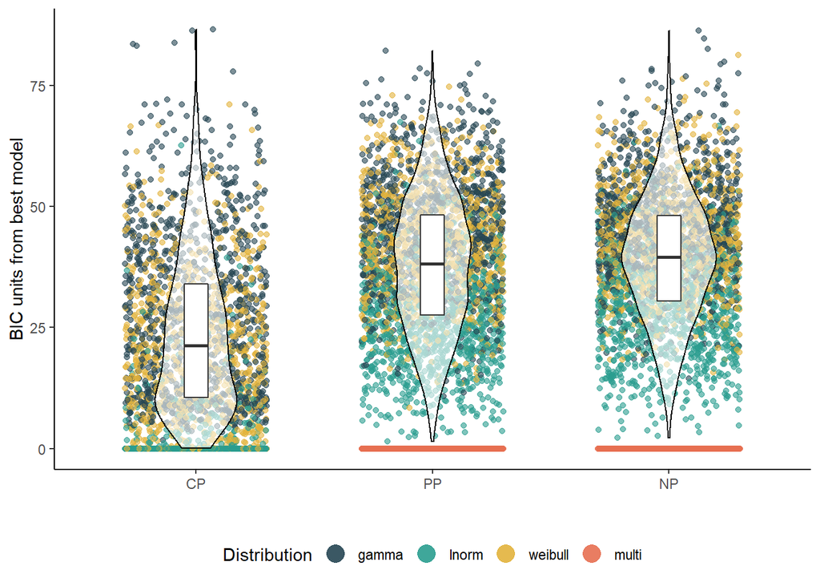

Figure 5 - Distributions of $\Delta BIC$ values for models under the three different pooling scenarios. Best fit model is aligned at y = 0, thus in the case of the PP and NP scenario, the orange bar at y=0 is actually the $\Delta BIC$ value being zero for the multi-distribution model for all bootstraps. The violin plots describe the density of $\Delta BIC$ units away from the best model. The box overlay shows the median, and lower and upper quartiles of this distribution for the three different pooling levels.

# Table 2 - Average BIC units from best model

Table 2 - Mean and median distance for second best model in BIC units, for each of the pooling scenarios.

```
## # A tibble: 3 x 6
##   model minimum median  mean  q2.5 q97.5
##   <fct>   <dbl>  <dbl> <dbl> <dbl> <dbl>
## 1 CP     0.0458   15.4  18.4 0.726  50.5
## 2 PP     1.49     24.1  24.4 6.86   44.1
## 3 NP     2.17     27.6  26.9 9.18   43.4
```

# Figure 6 - angles

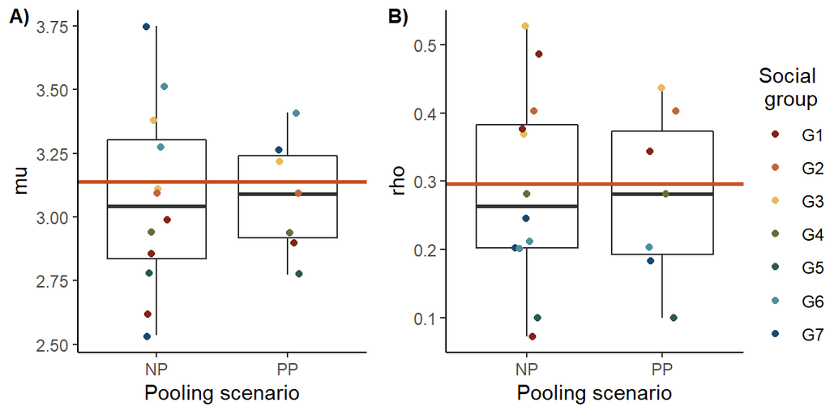

Figure 6 - Parameters estimated for a wrapped Cauchy distribution for relative angles for individuals, and social groups across the different pooling levels. Color is used to describe the social groups to which individuals belong to. The orange line on both plots represents the parameter values estimated using all the data under the complete pooling approach.